# NBA 2023 Champion Prediction

Ma

2023-04-22

## 1. Executive Summary

I’m working on a fun project called “NBA 2023 Champion Prediction”. Basically, I’m using historical data and machine learning to try and figure out which NBA team is most likely to win the championship in 2023.

The NBA is so popular, and people love making predictions about which team will come out on top. So, I’m using historical regular season team stats, game results, and other data to train machine learning models that can predict the number of wins of each team in the playoffs. The team winning the most games in the 2023 playoff will be the championship.

It’s interesting to see how accurate my predictions are, and I will buy sports lottery tickets according to my prediction.

## 2. Data Introduction

For this project, I scraped NBA regular season data from the website https://www.basketball-reference.com/. The website provides a comprehensive collection of NBA statistics, game results, and player information from past seasons.

I collected data for the 2000 - 2023 NBA regular seasons. The data includes information on team statistics, game results, and other relevant metrics such as team standings, player awards, and playoff results.

Overall, the data collected from basketball-reference.com provides a rich and diverse set of features that are essential for accurate prediction of NBA team performance.

## 3. Libraries

```r
library(rvest)
library(tidyverse)
```

```r
library(stringr)
library(DataExplorer)
library(corrplot)
library(ranger)
library(janitor)
library(caret)
library(randomForest)
library(xgboost)
```

## 4. Web Scraping

- regular season

Division Standings East

```r
division_total_E <- data.frame()

# Loop through the years from 2000 to 2023
for (year in 2000:2023) {
  # Specify the URL for each year
  url <- paste0("https://www.basketball-reference.com/leagues/NBA_", year, ".html")

  # Read the HTML code from the page
  html <- read_html(url)

  # Extract the Per Game Stats table using CSS selector
  division_standings_E <- html %>%
    html_nodes("#divs_standings_E") %>%
    html_table() %>%
    as.data.frame()
  # Rename the columns of the data frame
  colnames(division_standings_E) <- c("Eastern_Conference", "W", "L", "W/L_percent", "GB", "PS/G", "PA/G", "SRS")
  # Add a "Year" column to the dataframe and store the data
  division_standings_E$Year <- year
  division_total_E <- bind_rows(division_total_E , division_standings_E)
}

# View the data
division_total_E
```

Division Standings West

```r
division_total_W <- data.frame()

# Loop through the years from 2000 to 2023
for (year in 2000:2023) {
  # Specify the URL for each year
  url <- paste0("https://www.basketball-reference.com/leagues/NBA_", year, ".html")

  # Read the HTML code from the page
  html <- read_html(url)

  # Extract the Per Game Stats table using CSS selector
  division_standings_W <- html %>%
    html_nodes("#divs_standings_W") %>%
    html_table() %>%
    as.data.frame()
  # Rename the columns of the data frame
  colnames(division_standings_W) <- c("Western_Conference", "W", "L", "W/L_percent", "GB", "PS/G", "PA/G", "SRS")
  # Add a "Year" column to the dataframe and store the data
  division_standings_W$Year <- year
  division_total_W <- bind_rows(division_total_W , division_standings_W)
}

# View the data
division_total_W
```

Per Game Stats

```r
# Create an empty dataframe to store the data
pergame_stats_total <- data.frame()

# Loop through the years from 2000 to 2023
for (year in 2000:2023) {
  # Specify the URL for each year
  url <- paste0("https://www.basketball-reference.com/leagues/NBA_", year, ".html")

  # Read the HTML code from the page
  html <- read_html(url)

  # Extract the Per Game Stats table using CSS selector
  per_game_stats <- html %>%
    html_nodes("#per_game-team") %>%
    html_table() %>%
    as.data.frame()

  # Rename the columns of the data frame
  colnames(per_game_stats) <- c("Rk", "Team", "G", "MP", "FG", "FGA", "FG_Percent", "3P", "3PA", "3P_Percent", "2P", "2PA", "2P_Percent", "FT", "FTA", "FT_Percent", "ORB", "DRB", "TRB", "AST", "STL", "BLK", "TOV", "PF", "PTS")

  # Add a "Year" column to the dataframe and store the data
  per_game_stats$Year <- year
  pergame_stats_total <- bind_rows(pergame_stats_total, per_game_stats)
}

# View the data
pergame_stats_total
```

Advanced Stats

```r
# Create an empty dataframe to store the data
advanced_stats_total <- data.frame()

# Loop through the years from 2000 to 2023
for (year in 2000:2023) {
  # Specify the URL for each year
  url <- paste0("https://www.basketball-reference.com/leagues/NBA_", year, ".html")

  # Read the HTML code from the page
  html <- read_html(url)

  # Extract the Per Game Stats table using CSS selector
  advanced_stats <- html %>%
    html_nodes("#advanced-team") %>%
    html_table() %>%
    as.data.frame()

  # Rename the columns of the data frame
  colnames(advanced_stats) <- c("Rk", "Team", "Age", "W", "L", "PW", "PL", "MOV", "SOS", "SRS", "OPtg", "DRtg", "NRtg", "Pace", "FTr", "3PAr", "TS_percent", "eFG_percent_offense", "TOV_percent_offense", "ORB_percent", "FT/FGA_offense", "eFG_percent_defense", "TOV_percent_defense", "DRB_percent", "FT/FGA_defense", "Arena", "Attend", "Attend/G")

  # Add a "Year" column to the dataframe and store the data
  advanced_stats$Year <- year
  advanced_stats_total <- bind_rows(advanced_stats_total, advanced_stats)
}

# View the data
advanced_stats_total
```

- playoffs

advanced stats

```r
WL_playoff_total <- data.frame()

for (year in 2000:2023){
  # Specify the URL for each year
  url <- paste0("https://www.basketball-reference.com/playoffs/NBA_", year, ".html")

  # Read the HTML code from the page
  html <- read_html(url)

  # Extract the Per Game Stats table using CSS selector
  WL_playoff <- html %>%
    html_nodes("#advanced-team") %>%
    html_table() %>%
    as.data.frame()

# Rename the columns of the data frame
  colnames(WL_playoff) <- c("Rk", "Team", "Age", "W", "L", "WL_percent", "PW", "PL", "OPtg", "DRtg", "NRtg", "Pace", "FTr", "3PAr", "TS_percent", "eFG_percent_offense", "TOV_percent_offense", "ORB_percent", "FT/FGA_offense", "eFG_percent_defense", "TOV_percent_defense", "DRB_percent", "FT/FGA_defense")

# Add a "Year" column to the dataframe and store the data
  WL_playoff$Year <- year
  WL_playoff_total <- bind_rows(WL_playoff_total, WL_playoff)
}
```

```r
#writing the data I scraped into excel
write.csv(division_total_E, "C:/Users/PC/Documents/BA/R Data Science/More Cases/2023 NBA Prediction/division_total_E.csv")
write.csv(division_total_W, "C:/Users/PC/Documents/BA/R Data Science/More Cases/2023 NBA Prediction/division_total_W.csv")
write.csv(pergame_stats_total, "C:/Users/PC/Documents/BA/R Data Science/More Cases/2023 NBA Prediction/pergame_stats_total.csv")
write.csv(advanced_stats_total, "C:/Users/PC/Documents/BA/R Data Science/More Cases/2023 NBA Prediction/advanced_stats_total.csv")
write.csv(WL_playoff_total, "C:/Users/PC/Documents/BA/R Data Science/More Cases/2023 NBA Prediction/WL_playoff_total.csv")
```

## 5. Read file into R

```r
path = "C:/Users/PC/Documents/BA/R Data Science/More Cases/2023 NBA Prediction/"
#Read in eaah dataset
division_total_E <- read_csv(paste0(path, "division_total_E.csv"))
```

```
## ──────────────────────────────────────────────────────── Delimiter: "," chr
## (8): Eastern_Conference, W, L, W/L_percent, GB, PS/G, PA/G, SRS dbl (2): ...1,
## Year
```

```r
division_total_W <- read_csv(paste0(path, "division_total_W.csv"))
```

```
## ──────────────────────────────────────────────────────── Delimiter: "," chr
## (8): Western_Conference, W, L, W/L_percent, GB, PS/G, PA/G, SRS dbl (2): ...1,
## Year
```

```r
pergame_stats_total <- read_csv(paste0(path, "pergame_stats_total.csv"))
```

```
## ──────────────────────────────────────────────────────── Delimiter: "," chr
## (1): Team dbl (26): ...1, Rk, G, MP, FG, FGA, FG_Percent, 3P, 3PA, 3P_Percent,
## 2P, 2PA...
```

```r
advanced_stats_total <- read_csv(paste0(path, "advanced_stats_total.csv"))
```

```
## ──────────────────────────────────────────────────────── Delimiter: "," chr
## (28): Rk, Team, Age, W, L, PW, PL, MOV, SOS, SRS, OPtg, DRtg, NRtg, Pace... dbl
## (2): ...1, Year lgl (3): eFG_percent_offense, TOV_percent_defense, Attend/G
```

```r
WL_playoff_total <- read_csv(paste0(path, "WL_playoff_total.csv"))
```

```
## ──────────────────────────────────────────────────────── Delimiter: "," chr
## (23): Rk, Team, Age, W, L, WL_percent, PW, PL, OPtg, DRtg, NRtg, Pace, F... dbl
## (2): ...1, Year lgl (2): eFG_percent_offense, TOV_percent_defense
```

Make a copy of each dataset and I will edit on the copies.

```r
division_E <- division_total_E
division_W <- division_total_W
pergame <- pergame_stats_total
advanced <- advanced_stats_total
playoff <- WL_playoff_total
head(division_E)
```

```
## # A tibble: 6 × 10
##    ...1 Eastern_Conference  W      L     `W/L_percent` GB    `PS/G` `PA/G` SRS
##   <dbl> <chr>               <chr>  <chr> <chr>         <chr> <chr>  <chr>  <chr>
## 1     1 Atlantic Division   Atlan… Atla… Atlantic Div… Atla… Atlan… Atlan… Atla…
## 2     2 Miami Heat*         52     30    .634          —     94.4   91.3   2.75
## 3     3 New York Knicks*    50     32    .610          2.0   92.1   90.7   1.30
## 4     4 Philadelphia 76ers* 49     33    .598          3.0   94.8   93.4   1.02
## 5     5 Orlando Magic       41     41    .500          11.0  100.1  99.4   0.43
## 6     6 Boston Celtics      35     47    .427          17.0  99.3   100.1  -1.00
## # ℹ 1 more variable: Year <dbl>
```

```r
head(division_W)
```

```
## # A tibble: 6 × 10
##    ...1 Western_Conference   W     L     `W/L_percent` GB    `PS/G` `PA/G` SRS
##   <dbl> <chr>                <chr> <chr> <chr>         <chr> <chr>  <chr>  <chr>
## 1     1 Midwest Division     Midw… Midw… Midwest Divi… Midw… Midwe… Midwe… Midw…
## 2     2 Utah Jazz*           55    27    .671          —     96.5   92.0   4.52
## 3     3 San Antonio Spurs*   53    29    .646          2.0   96.2   90.2   5.92
## 4     4 Minnesota Timberwol… 50    32    .610          5.0   98.5   96.0   2.67
## 5     5 Dallas Mavericks     40    42    .488          15.0  101.4  102.0  -0.29
## 6     6 Denver Nuggets       35    47    .427          20.0  99.0   101.1  -1.76
## # ℹ 1 more variable: Year <dbl>
```

```r
head(pergame)
```

```
## # A tibble: 6 × 27
##    ...1    Rk Team       G    MP    FG   FGA FG_Percent  `3P` `3PA` `3P_Percent`
##   <dbl> <dbl> <chr>  <dbl> <dbl> <dbl> <dbl>      <dbl> <dbl> <dbl>        <dbl>
## 1     1     1 Sacra…    82  242.  40    88.9      0.45    6.5  20.2        0.322
## 2     2     2 Detro…    82  242.  37.1  80.9      0.459   5.4  14.9        0.359
## 3     3     3 Dalla…    82  241.  39    85.9      0.453   6.3  16.2        0.391
## 4     4     4 India…    82  241.  37.2  81        0.459   7.1  18.1        0.392
## 5     5     5 Milwa…    82  242.  38.7  83.3      0.465   4.8  13          0.369
## 6     6     6 Los A…    82  242.  38.3  83.4      0.459   4.2  12.8        0.329
## # ℹ 16 more variables: `2P` <dbl>, `2PA` <dbl>, `2P_Percent` <dbl>, FT <dbl>,
## #   FTA <dbl>, FT_Percent <dbl>, ORB <dbl>, DRB <dbl>, TRB <dbl>, AST <dbl>,
## #   STL <dbl>, BLK <dbl>, TOV <dbl>, PF <dbl>, PTS <dbl>, Year <dbl>
```

```r
head(advanced)
```

```
## # A tibble: 6 × 33
##    ...1 Rk    Team   Age   W     L     PW    PL    MOV   SOS   SRS   OPtg  DRtg
##   <dbl> <chr> <chr>  <chr> <chr> <chr> <chr> <chr> <chr> <chr> <chr> <chr> <chr>
## 1     1 Rk    Team   Age   W     L     PW    PL    MOV   SOS   SRS   ORtg  DRtg
## 2     2 1     Los A… 29.2  67    15    64    18    8.55  -0.14 8.41  107.3 98.2
## 3     3 2     Portl… 29.6  59    23    59    23    6.40  -0.04 6.36  107.9 100.8
## 4     4 3     San A… 30.9  53    29    58    24    5.94  -0.02 5.92  105.0 98.6
## 5     5 4     Phoen… 28.6  53    29    56    26    5.22  0.02  5.24  104.6 99.0
## 6     6 5     Utah … 31.5  55    27    54    28    4.46  0.05  4.52  107.3 102.3
## # ℹ 20 more variables: NRtg <chr>, Pace <chr>, FTr <chr>, `3PAr` <chr>,
## #   TS_percent <chr>, eFG_percent_offense <lgl>, TOV_percent_offense <chr>,
## #   ORB_percent <chr>, `FT/FGA_offense` <chr>, eFG_percent_defense <chr>,
## #   TOV_percent_defense <lgl>, DRB_percent <chr>, `FT/FGA_defense` <chr>,
## #   Arena <chr>, Attend <chr>, `Attend/G` <lgl>, ...30 <chr>, ...31 <chr>,
## #   ...32 <chr>, Year <dbl>
```

```r
head(playoff)
```

```
## # A tibble: 6 × 27
##    ...1 Rk    Team    Age   W     L     WL_percent PW    PL    OPtg  DRtg  NRtg
##   <dbl> <chr> <chr>   <chr> <chr> <chr> <chr>      <chr> <chr> <chr> <chr> <chr>
## 1     1 Rk    Tm      Age   W     L     W/L%       PW    PL    ORtg  DRtg  NRtg
## 2     2 1     Portla… 30.0  10    6     .625       11    5     107.7 102.2 +5.5
## 3     3 2     Miami … 29.6  6     4     .600       6     4     97.4  94.4  +3.0
## 4     4 3     Indian… 30.9  13    10    .565       14    9     109.7 106.8 +2.9
## 5     5 4     Los An… 29.3  15    8     .652       13    10    110.1 107.5 +2.6
## 6     6 5     Milwau… 27.6  2     3     .400       3     2     107.5 105.5 +2.0
## # ℹ 15 more variables: Pace <chr>, FTr <chr>, `3PAr` <chr>, TS_percent <chr>,
## #   eFG_percent_offense <lgl>, TOV_percent_offense <chr>, ORB_percent <chr>,
## #   `FT/FGA_offense` <chr>, eFG_percent_defense <chr>,
## #   TOV_percent_defense <lgl>, DRB_percent <chr>, `FT/FGA_defense` <chr>,
## #   ...25 <chr>, ...26 <chr>, Year <dbl>
```

## 6. Data Cleaning

- division_E & division_W
1. Remove the row with unuseful value, including “Central Division”, “Atlantic Division”, “Southeast Division”, “Midwest Division”, ““Pacific Division”, “Southwest Division”, and “Northwest Division”.
2. GB :“Games behind” is a term used in the NBA standings to indicate the difference in the number of games won and lost between two teams. It represents the distance between a team’s position in the standings and the team that is currently leading the division or conference. The teams with “-” value of “GB” means they ranked #1 of their divisions in the regular season that year so I will replace the value with 0.
3. There are some values in the “Eastern_Conference” column contain “star”. The teams with “star” mean they made for the playoff that year. However, I don’t need that information so I am going to remove “*“.
4. Drop the row id column.

```r
#Remove the row with unuseful value
division_E <- division_E %>%
  filter(!Eastern_Conference %in% c("Central Division", "Atlantic Division", "Southeast Division"))
division_W <- division_W %>%
  filter(!Western_Conference %in% c("Midwest Division", "Pacific Division", "Southwest Division", "Northwest Division"))
#Replacing "-" with 0 in GB column
division_E$GB <- ifelse(division_E$GB == "—", 0, division_E$GB)
division_W$GB <- ifelse(division_W$GB == "—", 0, division_W$GB)
#Remove "*" in Eastern_Conference and Western_Conference
Eastern_Conference_clean <- division_E$Eastern_Conference %>%
  str_remove_all(fixed("*"))
division_E <- division_E %>%
  mutate(Eastern_Conference = Eastern_Conference_clean)

Western_Conference_clean <- division_W$Western_Conference %>%
  str_remove_all(fixed("*"))
division_W <- division_W %>%
  mutate(Western_Conference = Western_Conference_clean)

#I don't need the row id column
division_E <- division_E[,-1]
division_W <- division_W[,-1]

head(division_E)
```

```
## # A tibble: 6 × 9
##   Eastern_Conference W     L     `W/L_percent` GB    `PS/G` `PA/G` SRS    Year
##   <chr>              <chr> <chr> <chr>         <chr> <chr>  <chr>  <chr> <dbl>
## 1 Miami Heat         52    30    .634          0     94.4   91.3   2.75   2000
## 2 New York Knicks    50    32    .610          2.0   92.1   90.7   1.30   2000
## 3 Philadelphia 76ers 49    33    .598          3.0   94.8   93.4   1.02   2000
## 4 Orlando Magic      41    41    .500          11.0  100.1  99.4   0.43   2000
## 5 Boston Celtics     35    47    .427          17.0  99.3   100.1  -1.00  2000
## 6 New Jersey Nets    31    51    .378          21.0  98.0   99.0   -1.18  2000
```

```r
head(division_W)
```

```
## # A tibble: 6 × 9
##   Western_Conference   W     L     `W/L_percent` GB    `PS/G` `PA/G` SRS    Year
##   <chr>                <chr> <chr> <chr>         <chr> <chr>  <chr>  <chr> <dbl>
## 1 Utah Jazz            55    27    .671          0     96.5   92.0   4.52   2000
## 2 San Antonio Spurs    53    29    .646          2.0   96.2   90.2   5.92   2000
## 3 Minnesota Timberwol… 50    32    .610          5.0   98.5   96.0   2.67   2000
## 4 Dallas Mavericks     40    42    .488          15.0  101.4  102.0  -0.29  2000
## 5 Denver Nuggets       35    47    .427          20.0  99.0   101.1  -1.76  2000
## 6 Houston Rockets      34    48    .415          21.0  99.5   100.3  -0.57  2000
```

- pergame
1. Drop the “League Average” value in “Team” column.
2. There are some values in the “Team” column contain “star”. The teams with “star” mean they made for the playoff that year. However, I don’t need that information so I am going to remove “*“.
3. Drop the row id column.

```r
#Remove the row with unuseful value
pergame <- pergame %>%
  filter(!Team %in% "League Average")
#Remove "*" in Team
team_clean <- pergame$Team %>%
  str_remove_all(fixed("*"))
pergame <- pergame %>%
  mutate(Team = team_clean)

#I don't need the row id column
pergame <- pergame[,-1]

head(pergame)
```

```
## # A tibble: 6 × 26
##      Rk Team       G    MP    FG   FGA FG_Percent  `3P` `3PA` `3P_Percent`  `2P`
##   <dbl> <chr>  <dbl> <dbl> <dbl> <dbl>      <dbl> <dbl> <dbl>        <dbl> <dbl>
## 1     1 Sacra…    82  242.  40    88.9      0.45    6.5  20.2        0.322  33.4
## 2     2 Detro…    82  242.  37.1  80.9      0.459   5.4  14.9        0.359  31.8
## 3     3 Dalla…    82  241.  39    85.9      0.453   6.3  16.2        0.391  32.6
## 4     4 India…    82  241.  37.2  81        0.459   7.1  18.1        0.392  30
## 5     5 Milwa…    82  242.  38.7  83.3      0.465   4.8  13          0.369  33.9
## 6     6 Los A…    82  242.  38.3  83.4      0.459   4.2  12.8        0.329  34.1
## # ℹ 15 more variables: `2PA` <dbl>, `2P_Percent` <dbl>, FT <dbl>, FTA <dbl>,
## #   FT_Percent <dbl>, ORB <dbl>, DRB <dbl>, TRB <dbl>, AST <dbl>, STL <dbl>,
## #   BLK <dbl>, TOV <dbl>, PF <dbl>, PTS <dbl>, Year <dbl>
```

- advanced
1. The table format is incorrect in some columns so I have to fix it first.
2. Remove the row with unuseful value.
3. There are some values in the “Team” column contain “star”. The teams with “star” mean they made for the playoff that year. However, I don’t need that information so I am going to remove “*“.
4. Drop the row id column.

```r
#Fixing the columns
advanced <- subset(advanced, select = -c(eFG_percent_offense, TOV_percent_defense, `Attend/G`))
colnames(advanced)[19:29] <- c("eFG_percent_offense", "TOV_percent_offense", "ORB_percent", "FT/FGA_offense", "eFG_percent_defense", "TOV_percent_defense", "DRB_percent", "FT/FGA_defense", "Arena", "Attend", "Attend/G")

#Remove the row with unuseful value
advanced <- advanced %>%
  filter(!Team %in% "Team")

#Remove "*" in Team
team_clean <- advanced$Team %>%
  str_remove_all(fixed("*"))
advanced <- advanced %>%
  mutate(Team = team_clean)

#I don't need the row id column
advanced <- advanced[,-1]

#Removing comma in "Attend" and "Attend/G"
clean_strings_attend <- gsub(",", "", advanced$Attend)
clean_strings_attendG <- gsub(",", "", advanced$`Attend/G`)
advanced <- advanced %>%
  mutate(Attend = clean_strings_attend,
         `Attend/G` = clean_strings_attendG)
head(advanced)
```

```
## # A tibble: 6 × 29
##   Rk    Team   Age   W     L     PW    PL    MOV   SOS   SRS   OPtg  DRtg  NRtg
##   <chr> <chr>  <chr> <chr> <chr> <chr> <chr> <chr> <chr> <chr> <chr> <chr> <chr>
## 1 1     Los A… 29.2  67    15    64    18    8.55  -0.14 8.41  107.3 98.2  +9.1
## 2 2     Portl… 29.6  59    23    59    23    6.40  -0.04 6.36  107.9 100.8 +7.1
## 3 3     San A… 30.9  53    29    58    24    5.94  -0.02 5.92  105.0 98.6  +6.4
## 4 4     Phoen… 28.6  53    29    56    26    5.22  0.02  5.24  104.6 99.0  +5.6
## 5 5     Utah … 31.5  55    27    54    28    4.46  0.05  4.52  107.3 102.3 +5.0
## 6 6     India… 30.4  56    26    54    28    4.60  -0.45 4.15  108.5 103.6 +4.9
## # ℹ 16 more variables: Pace <chr>, FTr <chr>, `3PAr` <chr>, TS_percent <chr>,
## #   eFG_percent_offense <chr>, TOV_percent_offense <chr>, ORB_percent <chr>,
## #   `FT/FGA_offense` <chr>, eFG_percent_defense <chr>,
## #   TOV_percent_defense <chr>, DRB_percent <chr>, `FT/FGA_defense` <chr>,
## #   Arena <chr>, Attend <chr>, `Attend/G` <chr>, Year <dbl>
```

- playoff
1. Only keep the columns I need. “W”(wins in playoffs) as my dependent variable(Y). “Team” and “Year” as foregin keys.
2. Remove the row with unuseful value.
3. Drop the values in 2023 because this is what we going to predict.

```r
#Keeping "W", "Team" and "Year.
playoff <- playoff[,c(3,5,27)]

#Remove the row with unuseful value
playoff <- playoff %>%
  filter(!Team %in% c("Tm", "League Average", "Team"))

##Drop 2023
playoff <- playoff %>%
  filter(!Year %in% 2023)

head(playoff)
```

```
## # A tibble: 6 × 3
##   Team                   W      Year
##   <chr>                  <chr> <dbl>
## 1 Portland Trail Blazers 10     2000
## 2 Miami Heat             6      2000
## 3 Indiana Pacers         13     2000
## 4 Los Angeles Lakers     15     2000
## 5 Milwaukee Bucks        2      2000
## 6 New York Knicks        9      2000
```

More cleaning…

```r
#Some strange number in values of "Eastern_Conference" and "Western_Conference" in the year 2023.
division_E %>%
  filter(Year %in% 2023) %>%
  head()
```

```
## # A tibble: 6 × 9
##   Eastern_Conference   W     L     `W/L_percent` GB    `PS/G` `PA/G` SRS    Year
##   <chr>                <chr> <chr> <chr>         <chr> <chr>  <chr>  <chr> <dbl>
## 1 Boston Celtics (2)   57    25    .695          0     117.9  111.4  6.38   2023
## 2 Philadelphia 76ers … 54    28    .659          3.0   115.2  110.9  4.37   2023
## 3 New York Knicks (5)  47    35    .573          10.0  116.0  113.1  2.99   2023
## 4 Brooklyn Nets (6)    45    37    .549          12.0  113.4  112.5  1.03   2023
## 5 Toronto Raptors (9)  41    41    .500          16.0  112.9  111.4  1.59   2023
## 6 Milwaukee Bucks (1)  58    24    .707          0     116.9  113.3  3.61   2023
```

```r
division_W %>%
  filter(Year %in% 2023) %>%
  head()
```

```
## # A tibble: 6 × 9
##   Western_Conference   W     L     `W/L_percent` GB    `PS/G` `PA/G` SRS    Year
##   <chr>                <chr> <chr> <chr>         <chr> <chr>  <chr>  <chr> <dbl>
## 1 Denver Nuggets (1)   53    29    .646          0     115.8  112.5  3.04   2023
## 2 Minnesota Timberwol… 42    40    .512          11.0  115.8  115.8  -0.22  2023
## 3 Oklahoma City Thund… 40    42    .488          13.0  117.5  116.4  0.96   2023
## 4 Utah Jazz (12)       37    45    .451          16.0  117.1  118.0  -1.03  2023
## 5 Portland Trail Blaz… 33    49    .402          20.0  113.4  117.4  -3.96  2023
## 6 Sacramento Kings (3) 48    34    .585          0     120.7  118.1  2.30   2023
```

```r
#Remove the pattern "(number)" using gsub()
clean_strings_E <- gsub("\\s*\\(\\d+\\)\\s*", "", division_E$Eastern_Conference)
division_E <- division_E %>%
  mutate(Eastern_Conference = clean_strings_E)

clean_strings_W <- gsub("\\s*\\(\\d+\\)\\s*", "", division_W$Western_Conference)
division_W <- division_W %>%
  mutate(Western_Conference = clean_strings_W)
#Remove trail space
division_E$Eastern_Conference <- str_trim(division_E$Eastern_Conference)
division_W$Western_Conference <- str_trim(division_W$Western_Conference)


table(division_E$Eastern_Conference)
```

```
##
##       Atlanta Hawks      Boston Celtics       Brooklyn Nets   Charlotte Bobcats
##                  24                  24                  11                  10
##   Charlotte Hornets       Chicago Bulls Cleveland Cavaliers     Detroit Pistons
##                  12                  24                  24                  24
##      Indiana Pacers          Miami Heat     Milwaukee Bucks     New Jersey Nets
##                  24                  24                  24                  13
## New Orleans Hornets     New York Knicks       Orlando Magic  Philadelphia 76ers
##                   2                  24                  24                  24
##     Toronto Raptors  Washington Wizards
##                  24                  24
```

```r
length(table(division_E$Eastern_Conference))
```

```
## [1] 18
```

```r
table(division_E$Year)
```

```
##
## 2000 2001 2002 2003 2004 2005 2006 2007 2008 2009 2010 2011 2012 2013 2014 2015
##   15   15   15   15   15   15   15   15   15   15   15   15   15   15   15   15
## 2016 2017 2018 2019 2020 2021 2022 2023
##   15   15   15   15   15   15   15   15
```

```r
table(division_W$Western_Conference)
```

```
##
##                  Dallas Mavericks                    Denver Nuggets
##                                24                                24
##             Golden State Warriors                   Houston Rockets
##                                24                                24
##              Los Angeles Clippers                Los Angeles Lakers
##                                24                                24
##                 Memphis Grizzlies            Minnesota Timberwolves
##                                22                                24
##               New Orleans Hornets              New Orleans Pelicans
##                                 7                                10
## New Orleans/Oklahoma City Hornets             Oklahoma City Thunder
##                                 2                                15
##                      Phoenix Suns            Portland Trail Blazers
##                                24                                24
##                  Sacramento Kings                 San Antonio Spurs
##                                24                                24
##               Seattle SuperSonics                         Utah Jazz
##                                 9                                24
##               Vancouver Grizzlies
##                                 2
```

```r
length(table(division_W$Western_Conference))
```

```
## [1] 19
```

```r
table(division_W$Year)
```

```
##
## 2000 2001 2002 2003 2004 2005 2006 2007 2008 2009 2010 2011 2012 2013 2014 2015
##   14   14   14   14   14   15   15   15   15   15   15   15   15   15   15   15
## 2016 2017 2018 2019 2020 2021 2022 2023
##   15   15   15   15   15   15   15   15
```

There were 15 teams every year in the NBA East division and 14 or 15 teams in the West division but there were 18 teams and 19 teams in history, separately. The reason is that some teams changed their names over time.

## 7. Data Prearation

### 7.1 Merging Data

1. Change the names of “W” column in the playoff dataset.
2. Create a “performance” column in the playoff dataset.
3. Create a “division” column in division_E and division_W
4. Change the name of “Western_Conference” column and “Eastern_Conference”

```r
#Give the dependent variable a new name
colnames(playoff)[2] <- "wins_playoff"

#Create a column to distinguish teams that made to the playoff, teams that did not make the playoffs and teams that won the champion.
playoff$performance <- ""
playoff$wins_playoff <- as.numeric(playoff$wins_playoff)
playoff$performance <- ifelse((playoff$wins_playoff == 15 & playoff$Year == 2000:2002) | (playoff$wins_playoff == 16), "champion", "playoff")
head(playoff)
```

```
## # A tibble: 6 × 4
##   Team                   wins_playoff  Year performance
##   <chr>                         <dbl> <dbl> <chr>
## 1 Portland Trail Blazers           10  2000 playoff
## 2 Miami Heat                        6  2000 playoff
## 3 Indiana Pacers                   13  2000 playoff
## 4 Los Angeles Lakers               15  2000 champion
## 5 Milwaukee Bucks                   2  2000 playoff
## 6 New York Knicks                   9  2000 playoff
```

```r
#Create a column of division
division_E$division <- "E"
division_W$division <- "W"

#Change the names of columns
colnames(division_E)[1] <- "conference"
colnames(division_W)[1] <- "conference"
```

- create a “division” column in division_E and division_W

```r
division_E$division <- "E"
division_W$division <- "W"
```

Start merging each dataset

```r
#binding division_E and division_W
division_total <- rbind(division_E, division_W)
#changing the column name "conference" into "Team"
colnames(division_total)[1] <- "Team"
#Drop the duplicate columns that another dataset already have
division_total <- subset(division_total, select = -c(W, L, SRS))
#joining advanced with pergame
regular_season <- pergame %>%
  left_join(advanced, by = c("Team", "Year"), suffix = c("_pergame", "_advanced")) %>%
  left_join(division_total, by = c("Team", "Year"))
#joining playoff with regular_season
data <- regular_season %>%
  left_join(playoff, by = c("Team", "Year"))
#Give those who fail to make to the playoff that year a "fail" value in the column "performance"
data$performance <- ifelse(is.na(data$performance) == T, "fail", data$performance)
#Give a better name to column "W" and "L", which mean wins and loses in regular seasons
colnames(data)[29] <- "wins_regular"
colnames(data)[30] <- "loses_regular"

dim(data)
```

```
## [1] 715  60
```

### 7.2 Factorizing variables

Columns that should be numeric

```r
#Columns that should remain character
which(names(data) %in% c("Team", "Arena", "division", "performance"))
```

```
## [1]  2 51 58 60
```

```r
# specify the column indices to convert to numeric
numeric_cols <- setdiff(seq_along(data), c(2, 51, 58, 60))
# convert to numeric
data[, numeric_cols] <- apply(data[, numeric_cols], 2, as.numeric)
```

Columns that should be factors

```r
data$division <- as.factor(data$division)
data$performance <- as.factor(data$performance)
```

The goal is to predict the 2023 NBA champion.

```r
nba_2023 <- data %>%
  filter(Year == 2023) %>%
  select(-performance)

data <- data %>%
  filter(!Year %in% 2023)
```

## 8. Exploratory Data Analysis

```r
#create_report(data)
```

**Note : I will keep the “performance” column for EDA but I won’t use it later in modeling because we only know the champion “after” the whole season is over.**

### 8.1 The response variable : wins_playoff

```r
summary(data$wins_playoff)
```

```
##    Min. 1st Qu.  Median    Mean 3rd Qu.    Max.    NA's
##   0.000   1.000   3.500   5.181   7.250  16.000     321
```

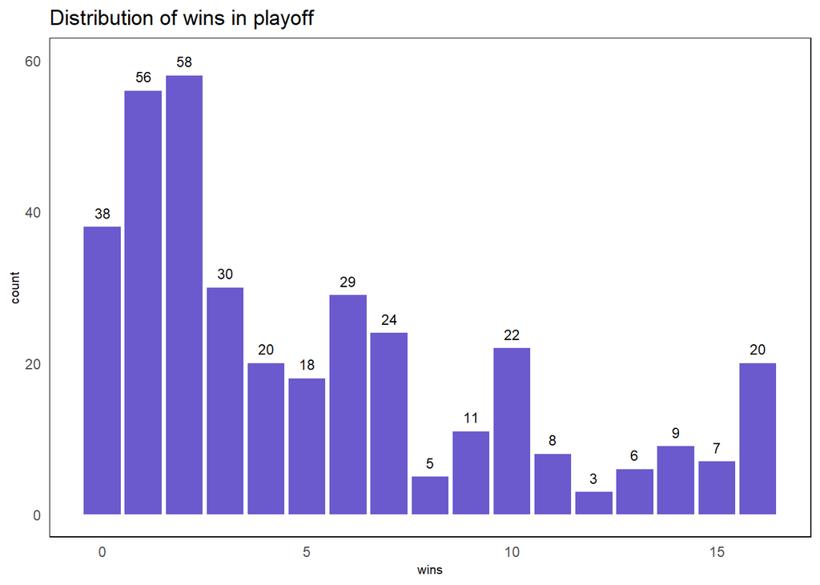

```r
data %>%
  count(wins_playoff) %>%
  ggplot(aes(wins_playoff, n)) +
  geom_col(fill = "slateblue") +
  labs(title = "Distribution of wins in playoff",
       x = "wins", y = "count") +
  theme_minimal() +
  theme(plot.title = element_text(size = 13),
        axis.title=element_text(size=8)) +
   theme(panel.background = element_rect(fill='white'),
          panel.grid.major = element_blank(),
          panel.grid.minor = element_blank())+
   geom_text(aes(label = n), size = 3, vjust = -0.8, color = "black") +
  ylim(0,60)
```

We can see that the distribution is skewed. This is simply because most of the teams lose in the first round of 16 to 8 matches.

### 8.2 Some interesting facts in regular seasons from 2000 to 2023

- FG_Percent : Field goals percentage per game

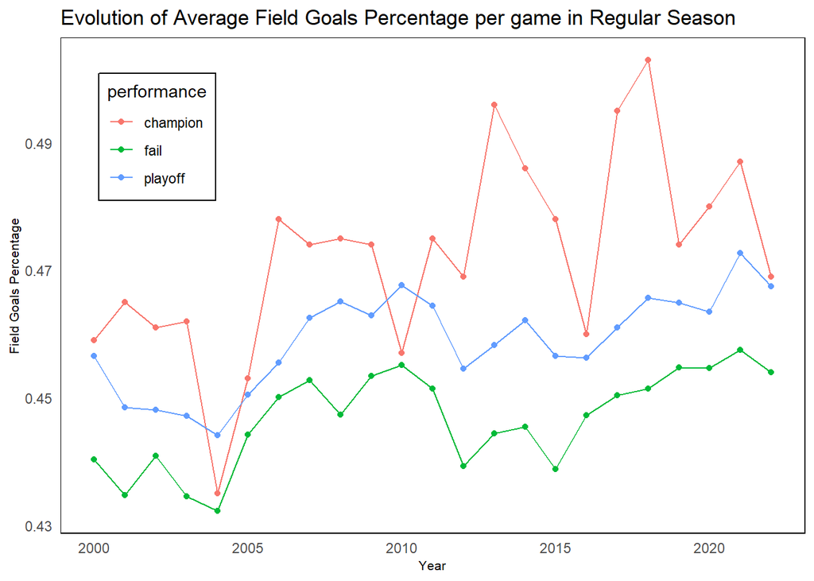

```r
data %>%
  group_by(Year, performance) %>%
  summarise(mean_FG_percent = mean(FG_Percent)) %>%
  ggplot(aes(Year, mean_FG_percent, group = performance, color =performance)) +
  geom_point() +
  geom_line()+
  labs(title = "Evolution of Average Field Goals Percentage per game in Regular Season",
       x = "Year", y = "Field Goals Percentage") +
  theme_minimal() +
  theme(plot.title = element_text(size = 13),
        axis.title=element_text(size=8)) +
   theme(panel.background = element_rect(fill='white'),
          panel.grid.major = element_blank(),
          panel.grid.minor = element_blank())+
  theme(legend.position = c(0.13, 0.8),
        legend.background = element_rect(fill = "white", color = "black"))
```

Not surprisingly, playoff teams have a much higher field goal percentage than non-playoff teams on average.

- 3P : 3-Point field goals
- 3PA : 3-Point field goals attempt
- 3P_Percent : 3-Point field foals percentage

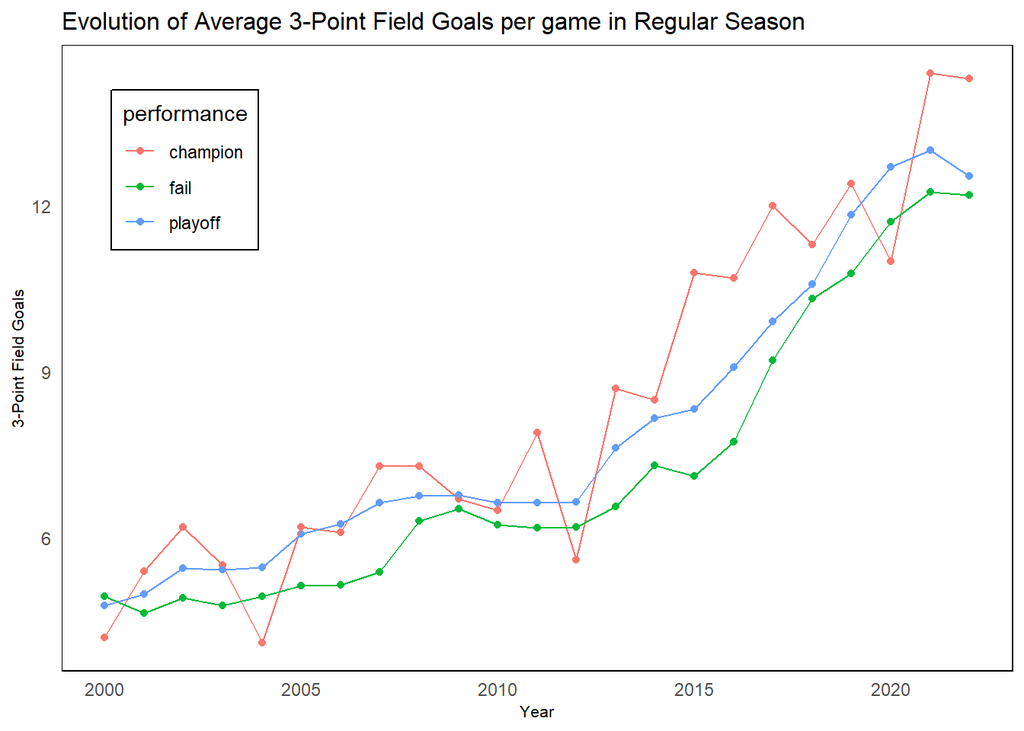

```r
data %>%
  group_by(Year, performance) %>%
  summarise(mean_3P = mean(`3P`)) %>%
  ggplot(aes(Year, mean_3P, group = performance, color =performance)) +
  geom_point() +
  geom_line()+
  labs(title = "Evolution of Average 3-Point Field Goals per game in Regular Season",
       x = "Year", y = "3-Point Field Goals") +
  theme_minimal() +
  theme(plot.title = element_text(size = 12),
        axis.title=element_text(size=8)) +
   theme(panel.background = element_rect(fill='white'),
          panel.grid.major = element_blank(),
          panel.grid.minor = element_blank())+
  theme(legend.position = c(0.13, 0.8),
        legend.background = element_rect(fill = "white", color = "black"))
```

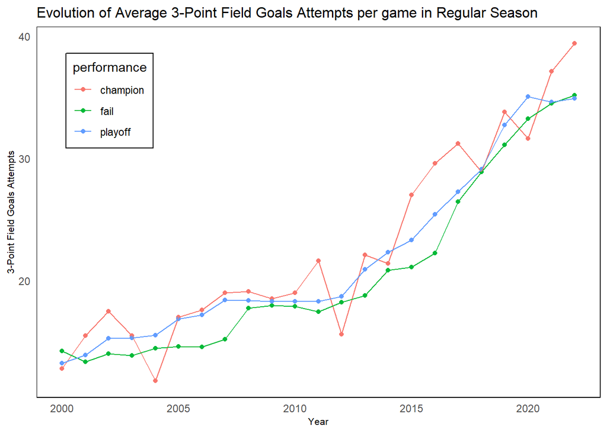

```r
data %>%
  group_by(Year, performance) %>%
  summarise(mean_3PA = mean(`3PA`)) %>%
  ggplot(aes(Year, mean_3PA, group = performance, color =performance)) +
  geom_point() +
  geom_line()+
  labs(title = "Evolution of Average 3-Point Field Goals Attempts per game in Regular Season",
       x = "Year", y = "3-Point Field Goals Attempts") +
  theme_minimal() +
  theme(plot.title = element_text(size = 12),
        axis.title=element_text(size=8)) +
   theme(panel.background = element_rect(fill='white'),
          panel.grid.major = element_blank(),
          panel.grid.minor = element_blank())+
  theme(legend.position = c(0.13, 0.8),
        legend.background = element_rect(fill = "white", color = "black"))
```

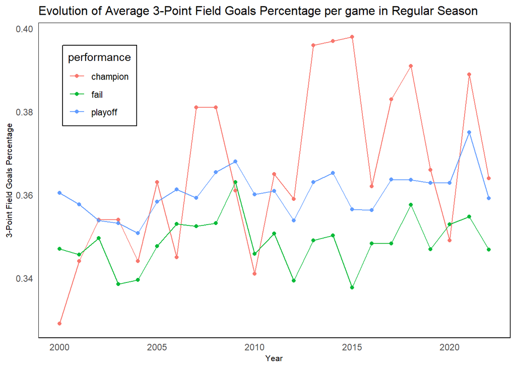

```r
data %>%
  group_by(Year, performance) %>%
  summarise(mean_3P_Percent = mean(`3P_Percent`)) %>%
  ggplot(aes(Year, mean_3P_Percent, group = performance, color =performance)) +
  geom_point() +
  geom_line()+
  labs(title = "Evolution of Average 3-Point Field Goals Percentage per game in Regular Season",
       x = "Year", y = "3-Point Field Goals Percentage") +
  theme_minimal() +
  theme(plot.title = element_text(size = 12),
        axis.title=element_text(size=8)) +
   theme(panel.background = element_rect(fill='white'),
          panel.grid.major = element_blank(),
          panel.grid.minor = element_blank())+
  theme(legend.position = c(0.13, 0.8),
        legend.background = element_rect(fill = "white", color = "black"))
```

- 2PA : 2-Point field goals attempt

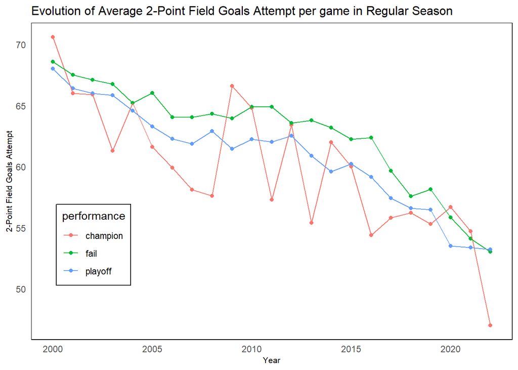

```r
data %>%
  group_by(Year, performance) %>%
  summarise(mean_2PA = mean(`2PA`)) %>%
  ggplot(aes(Year, mean_2PA, group = performance, color =performance)) +
  geom_point() +
  geom_line()+
  labs(title = "Evolution of Average 2-Point Field Goals Attempt per game in Regular Season",
       x = "Year", y = "2-Point Field Goals Attempt") +
  theme_minimal() +
  theme(plot.title = element_text(size = 12),
        axis.title=element_text(size=8)) +
   theme(panel.background = element_rect(fill='white'),
          panel.grid.major = element_blank(),
          panel.grid.minor = element_blank())+
  theme(legend.position = c(0.13, 0.3),
        legend.background = element_rect(fill = "white", color = "black"))
```

- PTS : Points

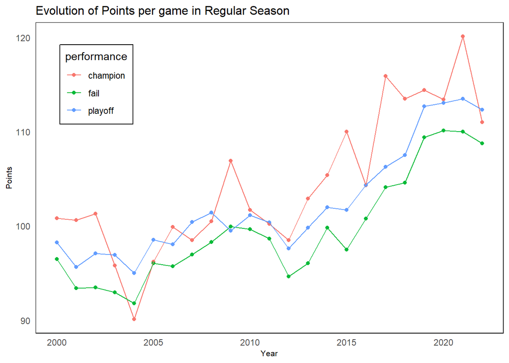

```r
data %>%
  group_by(Year, performance) %>%
  summarise(mean_PTS = mean(`PTS`)) %>%
  ggplot(aes(Year, mean_PTS, group = performance, color =performance)) +
  geom_point() +
  geom_line()+
  labs(title = "Evolution of Points per game in Regular Season",
       x = "Year", y = "Points") +
  theme_minimal() +
  theme(plot.title = element_text(size = 12),
        axis.title=element_text(size=8)) +
   theme(panel.background = element_rect(fill='white'),
          panel.grid.major = element_blank(),
          panel.grid.minor = element_blank())+
  theme(legend.position = c(0.13, 0.8),
        legend.background = element_rect(fill = "white", color = "black"))
```

## 9. Preparing data for modeling

Goal : Predict 2023 NBA champion using “nba_2023” as input. The “wins_playoff” will be the dependent variable(Y), and the teams with most wins will be the champion in prediction. The final independent variables(X) will be selected later using various methods.

```r
nba_2023 <- as.data.frame(nba_2023)
#Convert column "Team" to row index.
rownames(nba_2023) <- nba_2023$Team
#We don't need column "Team" and "Arena"
nba_2023 <- nba_2023 %>% select(-c(Team,Arena))
```

There are NAs in “Attend” and “Attend/G” column, and because the correlation between those features and “wins_playoff” are low, I decide to drop them.

```r
cor(data$Attend, data$wins_playoff,use="pairwise.complete.obs")
```

```
## [1] 0.09790018
```

```r
cor(data$`Attend/G`, data$wins_playoff,use="pairwise.complete.obs")
```

```
## [1] 0.1002934
```

```r
nba_2023 <- nba_2023 %>% select(-c(Attend, `Attend/G`))
data <- data %>% select(-c(Attend, `Attend/G`))
```

I only need the teams that made to the playoffs each year, and I don’t need the “performance”, “Team” and “Arena”(Having too much levels) column.

```r
data <- data %>%
  filter(performance %in% c("champion", "playoff")) %>%
  select(-c(performance,Arena))
```

Cleaning columns’ names

```r
data <- clean_names(data)
nba_2023 <- clean_names(nba_2023)
```

### 9.1 Feature Selection

Create a copy of data before feature selection

```r
data <- as.data.frame(data)
rownames(data) <- paste0(data$team, data$year)
data_2 <- data
```

- Finding variable importance with a quick Random Fores

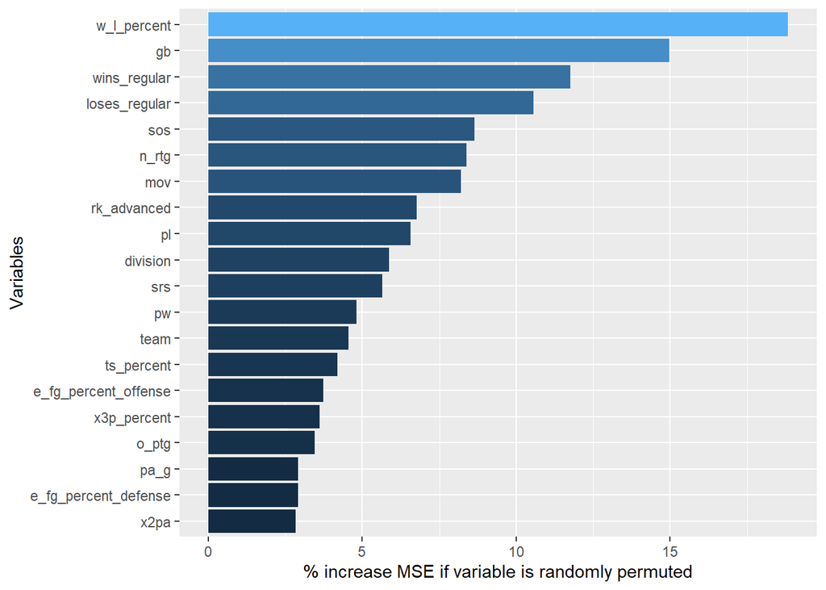

```r
set.seed(1234)
quick_rf <- randomForest(x=data[,-56], y=data$wins_playoff, ntree=500, importance = T)
important <- round(importance(quick_rf), 2)

imp_DF <- data.frame(Variables = row.names(important), MSE = important[,1])
imp_DF <- imp_DF[order(imp_DF$MSE, decreasing = TRUE),]
ggplot(imp_DF[1:20,], aes(x=reorder(Variables, MSE), y=MSE, fill=MSE)) + geom_bar(stat = 'identity') + labs(x = 'Variables', y= '% increase MSE if variable is randomly permuted') + coord_flip() + theme(legend.position="none")
```

Choose features having percent increase MSE higher than 5

```r
rf_features <- imp_DF %>% filter(MSE >5)
rf_features <- rf_features$Variables
```

- Find variables having higher than 0.5 correlation with “wins_playoff”

```r
numericVars <- which(map(data, is.numeric) == T)#index vector numeric variables
numericVarNames <- names(numericVars)#saving names vector for use later on
cat('There are', length(numericVars), 'numeric variables')
```

```
## There are 54 numeric variables
```

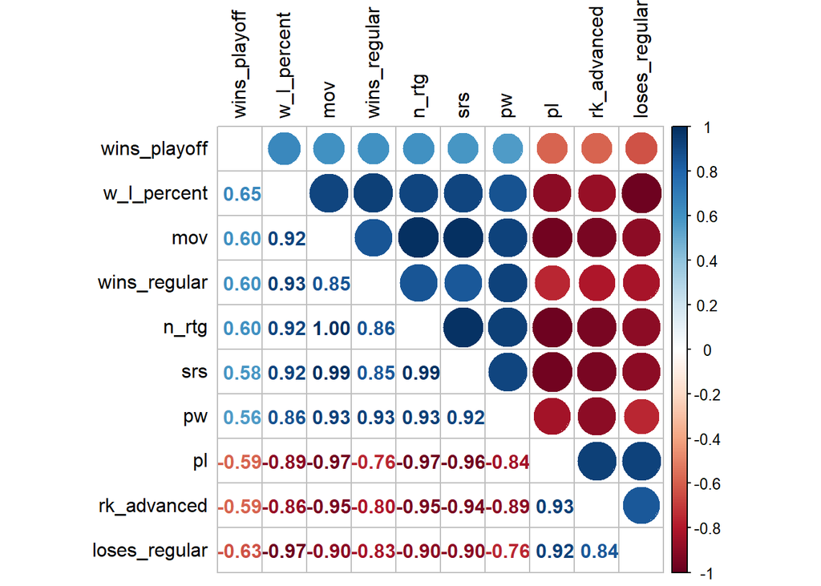

```r
#find correlations of all numeric variables
data_numVar <- data[, numericVars]
cor_numVar <- cor(data_numVar, use="pairwise.complete.obs")#pairwise.complete.obs uses the non-NA values when calculating the correlation.

#sort on decreasing correlations with SalePrice
cor_sorted <- as.matrix(sort(cor_numVar[,'wins_playoff'], decreasing = TRUE))

#select only high correlations with SalePrice(correlation>0.5)
CorHigh <- names(which(apply(cor_sorted, 1, function(x) abs(x)>0.5)))
cor_numVar <- cor_numVar[CorHigh, CorHigh]

#visiualization
corrplot.mixed(cor_numVar, tl.col = "black", tl.pos = "lt")
```

**It also becomes clear that multicollinearity is an issue when using some algorithms.**

```r
data <- data %>%
  select(c(rf_features, CorHigh, wins_playoff, year))
nba_2023 <- nba_2023 %>%
  select(c(rf_features, CorHigh, wins_playoff))
```

## 10. Modeling

I will use different training data to train models and test them on the same test set(year 2022).

### 10.1 Randomforest with training data in year 2000 to 2021

Composing training and testing sets

```r
training = data %>% filter(!year %in% 2022)
testing = data %>% filter(year %in% 2022)
#I don't need the "year" column when building models
training <- training[,-14]
testing <- testing[,-14]
dim(training)
```

```
## [1] 348  13
```

```r
dim(testing)
```

```
## [1] 16 13
```

#### 10.1.1 rf1

rf1 : Basic RF

```r
set.seed(1234)
rf1 <- randomForest(wins_playoff~., data = training, importance = T)
rf1
```

```
##
## Call:
##  randomForest(formula = wins_playoff ~ ., data = training, importance = T)
##                Type of random forest: regression
##                      Number of trees: 500
## No. of variables tried at each split: 4
##
##           Mean of squared residuals: 11.4862
##                     % Var explained: 48.01
```

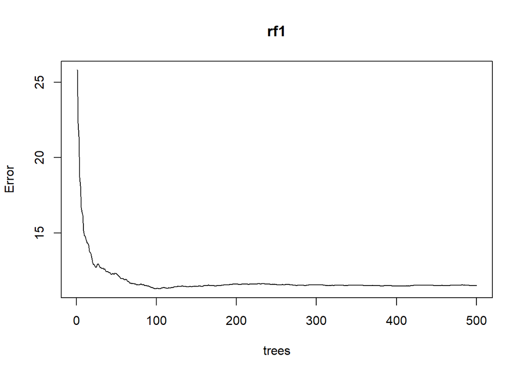

```r
plot(rf1)
```

```r
#The number of trees that minimize the MSE.
which.min(rf1$mse)
```

```
## [1] 98
```

```r
#The RMSE of the most suitable random forest is (the error value of the average Sale_Price):
sqrt(rf1$mse[which.min(rf1$mse)])
```

```
## [1] 3.358748
```

```r
save(rf1, file = "model.Rdata.rf1")
```

```r
load(file = "model.Rdata.rf1")
```

Finding Variable importance

```r
round(importance(rf1), 2)
```

```
##               %IncMSE IncNodePurity
## w_l_percent     19.40       1384.17
## gb              17.21        958.86
## wins_regular    14.20        608.53
## loses_regular   14.09        912.59
## sos             14.80        596.62
## n_rtg            9.47        562.44
## mov             12.73        724.51
## rk_advanced     10.76        388.30
## pl               9.09        289.68
## division        13.57        163.97
## srs              8.75        481.99
## pw               9.44        259.14
```

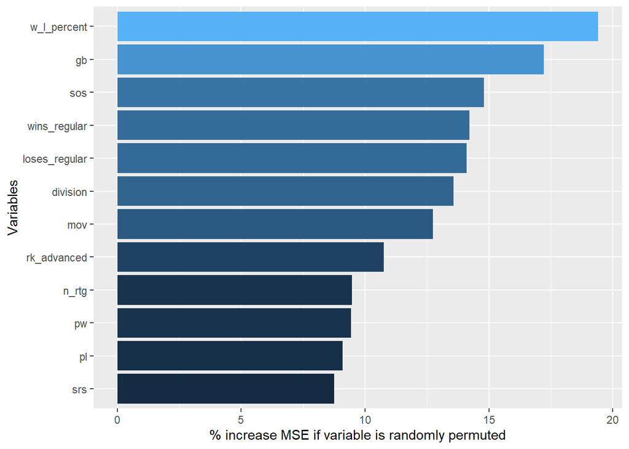

```r
important <- importance(rf1)
imp_DF <- data.frame(Variables = row.names(important), MSE = important[,1])
imp_DF <- imp_DF[order(imp_DF$MSE, decreasing = TRUE),]
ggplot(imp_DF, aes(x=reorder(Variables, MSE), y=MSE, fill=MSE)) + geom_bar(stat = 'identity') + labs(x = 'Variables', y= '% increase MSE if variable is randomly permuted') + coord_flip() + theme(legend.position="none")
```

rf1 prediction

```r
prediction_rf1 <- predict(rf1, testing[, -12])
rf1_MSE <- mean((prediction_rf1 - testing$wins_playoff)^2)
rf1_RMSE <- sqrt(rf1_MSE)
```

#### 10.1.2 rf2

Tuning

- tuneRF

Finding best mtry

```r
# Filter out predictor variable names
features <- setdiff(x = names(training), y = "wins_playoff")
set.seed(123)
RF_tune <- tuneRF(x = training[features], y = training$wins_playoff, mtryStart = 1, ntreeTry = 5000, trace = FALSE)
```

```
## -0.0206462 0.05
```

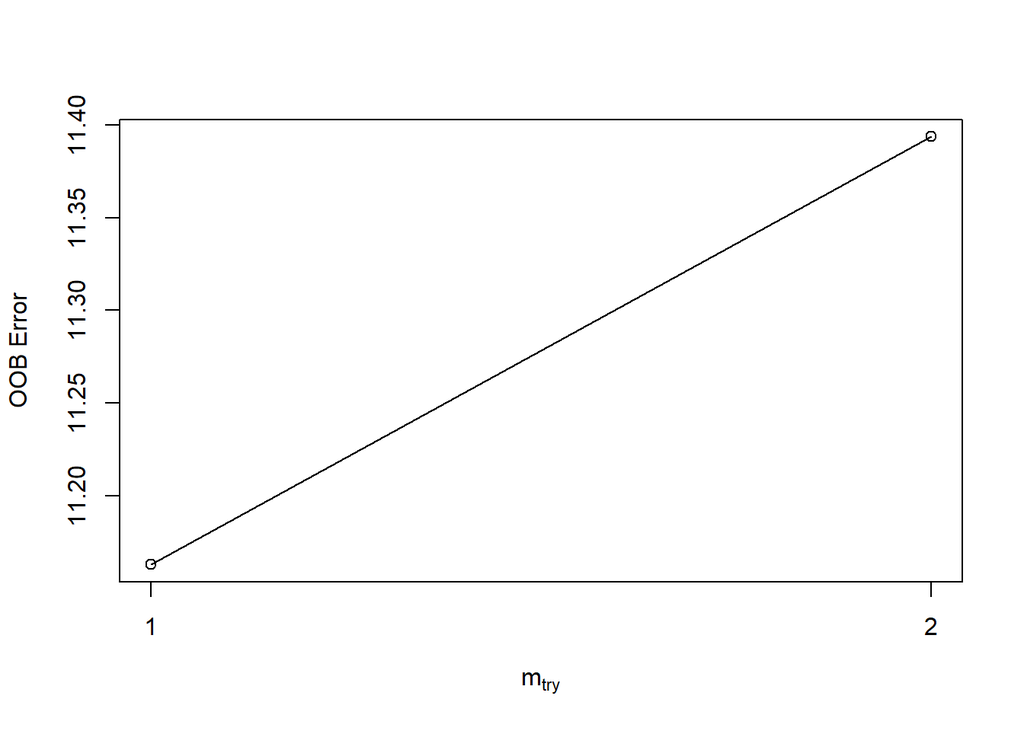

```r
RF_tune
```

```
##   mtry OOBError
## 1    1 11.16308
## 2    2 11.39356
```

Best mtry is 1.

- ranger

```r
# hyperparameter grid search
hyper_grid <- expand.grid(
  mtry = seq(1, 10, by = 1),
  node_size = seq(1, 9, by = 1),
  sample_size = c(0.55, 0.632, 0.7, 0.8),
  OOB_RMSE = 0
)

# total number of combinations
nrow(hyper_grid)
```

```
## [1] 360
```

```r
for (i in 1:nrow(hyper_grid)) {
  # train model
  ranger_tune <- ranger(
    formula = wins_playoff ~ .,
    data = training,
    num.trees = 500,
    mtry = hyper_grid$mtry[i],
    min.node.size = hyper_grid$node_size[i],
    sample.fraction = hyper_grid$sample_size[i],
    seed = 123
  )

  # 並將每一此訓練模型的OOB RMSE萃取儲存
  hyper_grid$OOB_RMSE[i] <- sqrt(ranger_tune$prediction.error)
}

# 我們將結果依序OOB_RMSE由小至大排列，取模型成效前十名印出
hyper_grid %>%
  dplyr::arrange(OOB_RMSE) %>%
  head(10)
```

```
##    mtry node_size sample_size OOB_RMSE
## 1     7         8        0.55 3.297908
## 2     7         7        0.55 3.298633
## 3    10         9        0.55 3.300885
## 4    10         8        0.55 3.301806
## 5     5         9        0.55 3.302102
## 6     7         9        0.55 3.304781
## 7     9         9        0.55 3.305087
## 8    10         7        0.55 3.305618
## 9     9         9        0.70 3.307140
## 10    5         8        0.55 3.307395
```

1. OOB_RMSE falls roughly around 3 games.
2. The optimal value of mtry falls in all 5~10 range intervals. Indicates that mtry does not have much impact on OOB_RMSE in this interval.
3. The number of optimal minimum node observations falls in the range of 7 to 9.
4. The optimal sampling ratio is about 0.55.

We repeat the model of this parameter setting 100 times to calculate the expected value of the error rate of this model.

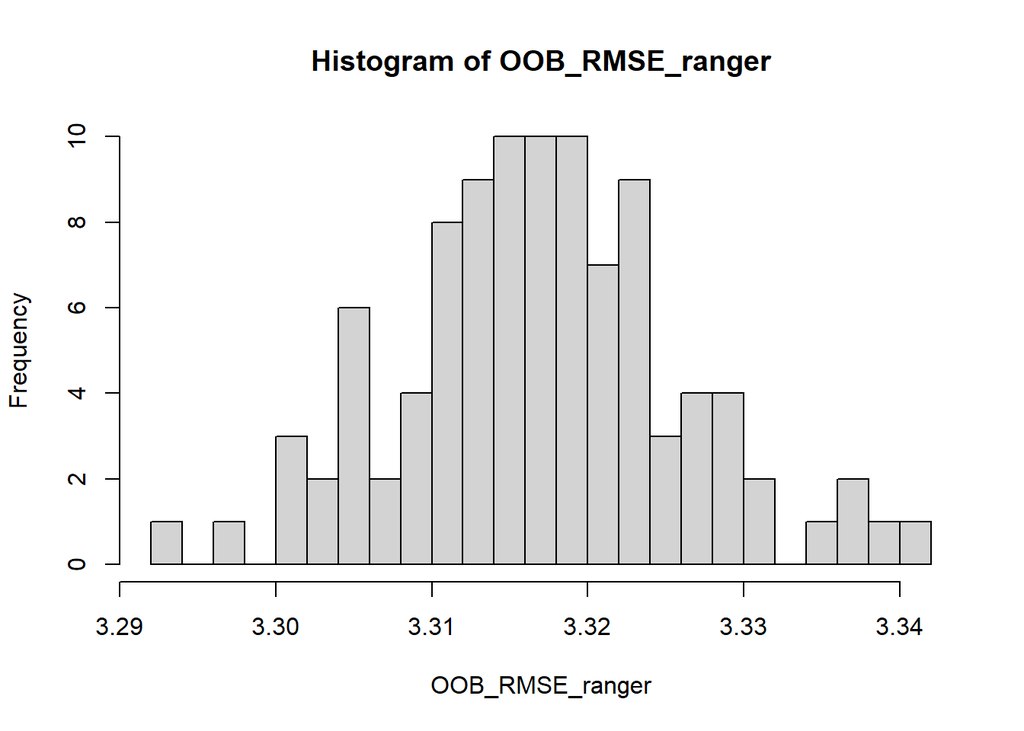

```r
OOB_RMSE_ranger <- vector(mode = "numeric", length = 100)

for(i in 1:length(OOB_RMSE_ranger)){
  optimal_ranger <- ranger(
    formula         = wins_playoff ~ .,
    data            = training,
    num.trees       = 500,
    mtry            = 7,
    min.node.size   = 8,
    sample.fraction = 0.55,
    importance      = 'impurity'
  )

  OOB_RMSE_ranger[i] <- sqrt(optimal_ranger$prediction.error)
}

hist(OOB_RMSE_ranger, breaks = 20)
```

- Build rf2 using parameters above

```r
rf2 <- ranger(
  formula = wins_playoff ~ .,
    data = training,
    num.trees = 500,
    mtry = 7,
    min.node.size = 8,
    sample.fraction = 0.55,
    seed = 123
)
save(rf2, file = "model.Rdata.rf2")
```

```r
load(file = "model.Rdata.rf2")
```

rf2 prediction

```r
prediction_rf2 <- predict(rf2, testing[,-12])
prediction_rf2 <- prediction_rf2$predictions
rf2_MSE <- mean((prediction_rf2 - testing$wins_playoff)^2)
rf2_RMSE <-  sqrt(rf2_MSE)
```

#### 10.1.3 rf3

try default mtry

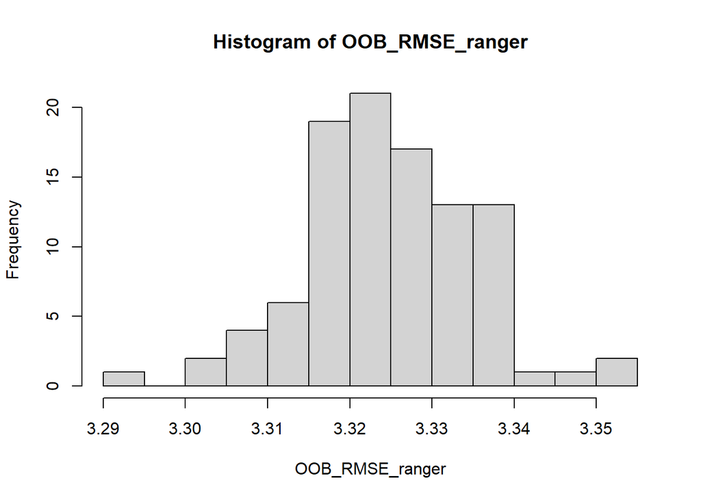

```r
OOB_RMSE_ranger <- vector(mode = "numeric", length = 100)

for(i in 1:length(OOB_RMSE_ranger)){
  optimal_ranger <- ranger(
    formula         = wins_playoff ~ .,
    data            = training,
    num.trees       = 500,
    min.node.size   = 8,
    sample.fraction = 0.55,
    importance      = 'impurity'
  )

  OOB_RMSE_ranger[i] <- sqrt(optimal_ranger$prediction.error)
}

hist(OOB_RMSE_ranger, breaks = 20)
```

```r
rf3 <- ranger(
  formula = wins_playoff ~ .,
    data = training,
    num.trees = 500,
    min.node.size   = 8,
    sample.fraction = 0.55,
    seed = 123
)
save(rf3, file = "model.Rdata.rf3")
```

```r
load(file = "model.Rdata.rf3")
```

rf3 prediction

```r
prediction_rf3 <- predict(rf3, testing[,-12])
prediction_rf3 <- prediction_rf3$predictions
rf3_MSE <- mean((prediction_rf3 - testing$wins_playoff)^2)
rf3_RMSE <-  sqrt(rf3_MSE)
```

### 10.2 Randomforest with training data in 2003 to 2022

```r
data = data %>% filter(!year %in% c(2000:2002))
training2 = data %>% filter(!year %in% 2022)
#I don't need the "year" column when building models
training2 <- training2[,-14]
dim(training2)
```

```
## [1] 302  13
```

#### 10.2.1 rf4

```r
rf4 <- ranger(
  formula = wins_playoff ~ .,
    data = training2,
    num.trees = 500,
    mtry = 7,
    min.node.size = 8,
    sample.fraction = 0.55,
    seed = 123
)
save(rf4, file = "model.Rdata.rf4")
```

```r
load(file = "model.Rdata.rf4")
```

rf4 prediction

```r
prediction_rf4 <- predict(rf4, testing[,-12])
prediction_rf4 <- prediction_rf4$predictions
rf4_MSE <- mean((prediction_rf4 - testing$wins_playoff)^2)
rf4_RMSE <-  sqrt(rf4_MSE)
```

### 10.3 Randomforest with training data in 2014 to 2022

The reason I pick this range is because teams focus more on 3-points field goals since then.

```r
data = data %>% filter(!year %in% c(2000:2013))
training3 = data %>% filter(!year %in% 2022)
#I don't need the "year" column when building models
training3 <- training3[,-14]
dim(training3)
```

```
## [1] 127  13
```

#### 10.3.1 rf5

```r
rf5 <- ranger(
  formula = wins_playoff ~ .,
    data = training3,
    num.trees = 500,
    mtry = 7,
    min.node.size = 8,
    sample.fraction = 0.55,
    seed = 123
)
save(rf5, file = "model.Rdata.rf5")
```

```r
load(file = "model.Rdata.rf5")
```

rf5 prediction

```r
prediction_rf5 <- predict(rf5, testing[,-12])
prediction_rf5 <- prediction_rf5$predictions
rf5_MSE <- mean((prediction_rf5 - testing$wins_playoff)^2)
rf5_RMSE <-  sqrt(rf5_MSE)
```

### 10.4 XGBoost with training data in 2003 to 2022

```r
# variable names
features <- setdiff(names(training2), "wins_playoff")
# Create the treatment plan from the training data
treatplan <- vtreat::designTreatmentsZ(training2, features, verbose = FALSE)

# Get the "clean" variable names from the scoreFrame
new_vars <- treatplan %>%
  magrittr::use_series(scoreFrame) %>%
  dplyr::filter(code %in% c("clean", "lev")) %>%
  magrittr::use_series(varName)

# Prepare the training data
features_train <- vtreat::prepare(treatplan, training2, varRestriction = new_vars) %>% as.matrix()
response_train <- training2$wins_playoff

# Prepare the test data
features_test <- vtreat::prepare(treatplan, testing, varRestriction = new_vars) %>% as.matrix()
response_test <- testing$wins_playoff

dim(features_train)
```

```
## [1] 302  13
```

```r
dim(features_test)
```

```
## [1] 16 13
```

- xgboost cv

To find the best nrounds

```r
set.seed(123)
xgb.fit1 <- xgb.cv(
  data = features_train,
  label = response_train,
  nrounds = 1000,
  nfold = 10,
  objective = 'reg:squarederror',  # for regression models
  verbose = 0  # silent,不要顯示詳細資訊
)
```

```r
print(xgb.fit1,verbose = TRUE)
```

```
## ##### xgb.cv 10-folds
## call:
##   xgb.cv(data = features_train, nrounds = 1000, nfold = 10, label = response_train,
##     verbose = 0, objective = "reg:squarederror")
## params (as set within xgb.cv):
##   objective = "reg:squarederror", silent = "1"
## callbacks:
##   cb.evaluation.log()
## niter: 1000
## evaluation_log:
##     iter train_rmse_mean train_rmse_std test_rmse_mean test_rmse_std
##        1     5.145431127    0.084181931       5.311948     0.9151569
##        2     4.014819961    0.059591623       4.530873     0.9453641
##        3     3.232333047    0.068063746       4.080418     0.8940909
##        4     2.654793427    0.079155921       3.868666     0.8192614
##        5     2.231607191    0.064028583       3.709725     0.7347971
## ---
##      996     0.001576238    0.000121107       3.726573     0.4827094
##      997     0.001576238    0.000121107       3.726573     0.4827094
##      998     0.001576238    0.000121107       3.726573     0.4827094
##      999     0.001576238    0.000121107       3.726573     0.4827094
##     1000     0.001576238    0.000121107       3.726573     0.4827094
```

```r
xgb.fit1$evaluation_log %>%
  dplyr::summarise(
    ntrees.train = which(train_rmse_mean == min(train_rmse_mean))[1],
    rmse.train   = min(train_rmse_mean),
    ntrees.test  = which(test_rmse_mean == min(test_rmse_mean))[1],
    rmse.test   = min(test_rmse_mean)
  )
```

```
##   ntrees.train  rmse.train ntrees.test rmse.test
## 1          424 0.001576238           9  3.577176
```

The detailed xgboost model iteration information is drawn as follows, the red line represents the training error, and the blue line represents the cross-validation error.

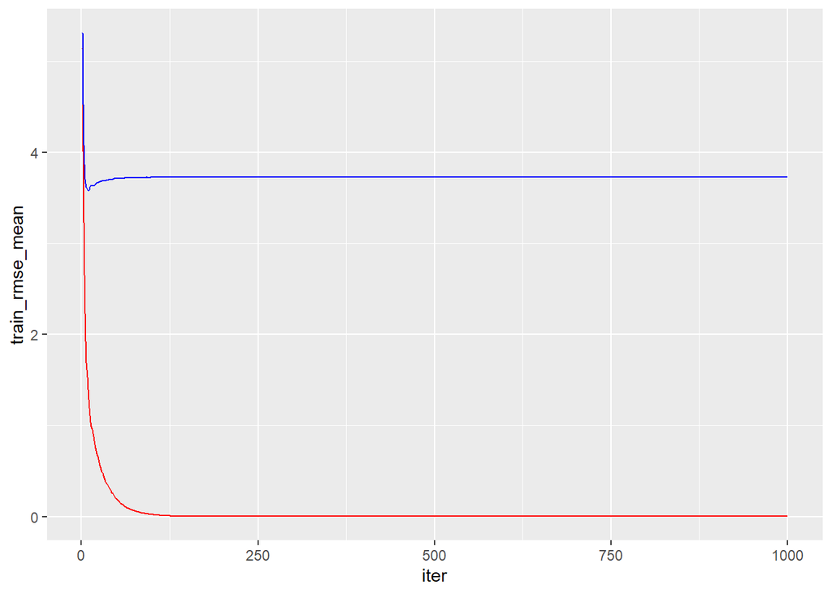

```r
# plot error vs number trees
ggplot(xgb.fit1$evaluation_log) +
  geom_line(aes(iter, train_rmse_mean), color = "red") +
  geom_line(aes(iter, test_rmse_mean), color = "blue")
```

Tuning

```r
# create hyperparameter grid
hyper_grid <- expand.grid(
  eta = c(.01, .05, .1, .3),
  max_depth = c(1:7),
  min_child_weight = c(1:7),
  subsample = c(.65,.7,.8, 1),
  colsample_bytree = c(.5,.6,.7,.8,.9, 1),
  optimal_trees = 0,               # a place to dump results
  min_RMSE = 0                     # a place to dump results
)

nrow(hyper_grid)
```

```
## [1] 4704
```

```r
# grid search
for(i in 1:nrow(hyper_grid)) {

  # create parameter list
  params <- list(
    eta = hyper_grid$eta[i],
    max_depth = hyper_grid$max_depth[i],
    min_child_weight = hyper_grid$min_child_weight[i],
    subsample = hyper_grid$subsample[i],
    colsample_bytree = hyper_grid$colsample_bytree[i]
  )

  # reproducibility
  set.seed(123)

  # train model
  xgb.tune <- xgb.cv(
    params = params,
    data = features_train,
    label = response_train,
    nrounds = 500,
    nfold = 10,
    objective = 'reg:squarederror',  # for regression models
    verbose = 0,               # silent,
    early_stopping_rounds = 10 # stop if no improvement for 10 consecutive trees
  )

  # add min training error and trees to grid
  hyper_grid$optimal_trees[i] <- which.min(xgb.tune$evaluation_log$test_rmse_mean)
  hyper_grid$min_RMSE[i] <- min(xgb.tune$evaluation_log$test_rmse_mean)
}

save(xgb.tune, file = "model.Rdata.xgb.tune")
save(hyper_grid, file = "model.Rdata.xgb_hyper_grid")
```

```r
load(file = "model.Rdata.xgb.tune")
load(file = "model.Rdata.xgb_hyper_grid")
```

```r
hyper_grid %>%
  dplyr::arrange(min_RMSE) %>%
  head(10)
```

```
##     eta max_depth min_child_weight subsample colsample_bytree optimal_trees
## 1  0.10         5                6       0.7              1.0            29
## 2  0.10         5                7       0.7              1.0            29
## 3  0.10         4                5       0.7              1.0            29
## 4  0.10         5                7       0.8              1.0            29
## 5  0.30         2                6       0.8              1.0            27
## 6  0.10         4                2       0.7              1.0            29
## 7  0.05         3                5       0.8              1.0            88
## 8  0.10         4                1       0.8              0.6            43
## 9  0.10         6                7       0.7              1.0            29
## 10 0.10         4                6       0.7              1.0            29
##    min_RMSE
## 1  3.290599
## 2  3.295362
## 3  3.305409
## 4  3.309496
## 5  3.313112
## 6  3.313654
## 7  3.314141
## 8  3.317956
## 9  3.317989
## 10 3.321103
```

- eta = 0.10
- max_depth = 5
- min_child_weight = 6
- subsample = 0.7
- colsample_bytree = 1.0

```r
# parameter list
params <- list(
  eta = 0.1,
  max_depth = 5,
  min_child_weight = 6,
  subsample = 0.7,
  colsample_bytree = 1.0
)

# train final model
xgb.fit.final <- xgboost(
  params = params,
  data = features_train,
  label = response_train,
  nrounds = 424, #From xgb.cv earlier
  objective = 'reg:squarederror',
  verbose = 0
)
save(xgb.fit.final, file = "model.Rdata.xgb.fit.final")
```

```r
load(file = "model.Rdata.xgb.fit.final")
```

Variable importance

```r
# create importance matrix
importance_matrix <- xgb.importance(model = xgb.fit.final)

importance_matrix
```

```
##              Feature       Gain       Cover  Frequency
##  1:      w_l_percent 0.17684653 0.077981210 0.08586724
##  2:               gb 0.16667365 0.073023757 0.08693790
##  3:              sos 0.12830137 0.177857033 0.21541756
##  4:              mov 0.12189073 0.144721516 0.12141328
##  5:              srs 0.08462406 0.156085153 0.12655246
##  6:      rk_advanced 0.06520816 0.052272246 0.05567452
##  7:    loses_regular 0.06236744 0.034365254 0.03618844
##  8:            n_rtg 0.05247345 0.108645220 0.10492505
##  9:     wins_regular 0.05143428 0.081550094 0.07066381
## 10:               pl 0.03758172 0.038697008 0.03875803
## 11:               pw 0.03356304 0.047721497 0.04753747
## 12: division_lev_x_E 0.01903556 0.007080012 0.01006424
```

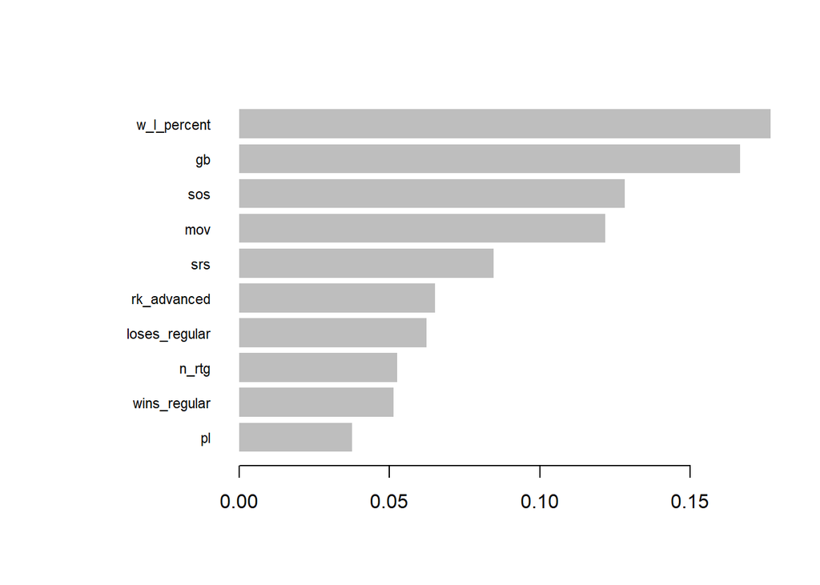

```r
# variable importance plot
xgb.plot.importance(importance_matrix, top_n = 10, measure = "Gain")
```

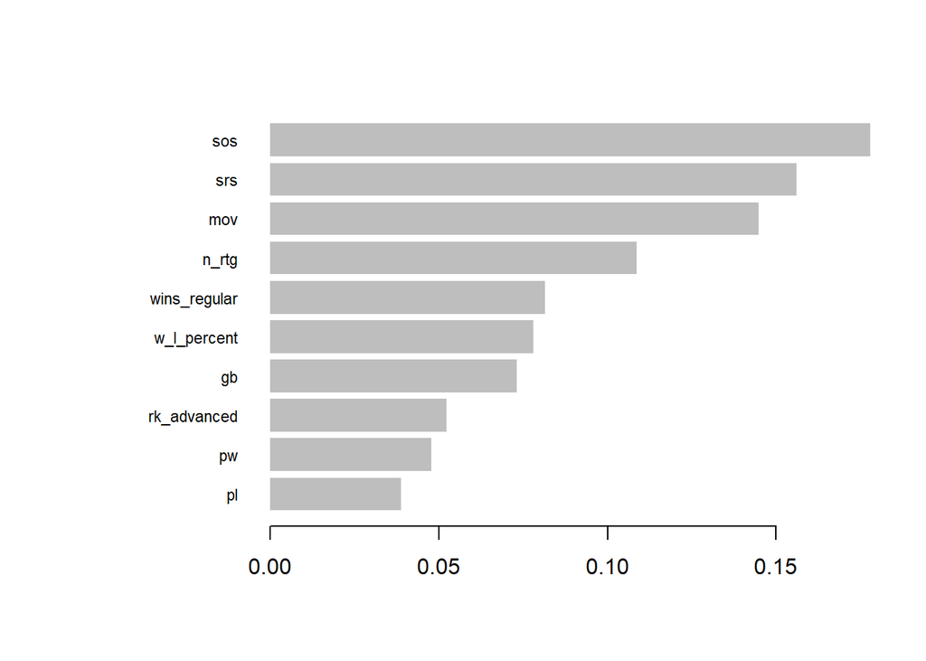

```r
# variable importance plot using 'cover'
xgb.plot.importance(importance_matrix, top_n = 10, measure = "Cover")
```

xgb.fit.final prediction

```r
# predict values for test data
prediction_xgbfinal <- predict(xgb.fit.final, features_test)

xgbfinal_MSE <- mean((prediction_xgbfinal - testing$wins_playoff)^2)
xgbfinal_RMSE <- sqrt(xgbfinal_MSE)
```

### 10.5 XGBoost with training data in 2014 to 2022

```r
# variable names
features <- setdiff(names(training3), "wins_playoff")
# Create the treatment plan from the training data
treatplan <- vtreat::designTreatmentsZ(training3, features, verbose = FALSE)

# Get the "clean" variable names from the scoreFrame
new_vars <- treatplan %>%
  magrittr::use_series(scoreFrame) %>%
  dplyr::filter(code %in% c("clean", "lev")) %>%
  magrittr::use_series(varName)

# Prepare the training data
features_train2 <- vtreat::prepare(treatplan, training3, varRestriction = new_vars) %>% as.matrix()
response_train2 <- training3$wins_playoff

dim(features_train2)
```

```
## [1] 127  13
```

```r
# parameter list
params <- list(
  eta = 0.1,
  max_depth = 5,
  min_child_weight = 6,
  subsample = 0.7,
  colsample_bytree = 1.0
)

# train final model
xgb.fit.final2 <- xgboost(
  params = params,
  data = features_train2,
  label = response_train2,
  nrounds = 424, #From xgb.cv earlier
  objective = 'reg:squarederror',
  verbose = 0
)
save(xgb.fit.final2, file = "model.Rdata.xgb.fit.final2")
```

```r
load(file = "model.Rdata.xgb.fit.final2")
```

xgb.fit.final2 prediction

```r
# predict values for test data
prediction_xgbfinal2 <- predict(xgb.fit.final2, features_test)

xgbfinal2_MSE <- mean((prediction_xgbfinal2 - testing$wins_playoff)^2)
xgbfinal2_RMSE <- sqrt(xgbfinal2_MSE)
```

## 11. Error Analysis

```r
algorithm <- c("RF", "RF", "RF", "RF", "RF", "XGB", "XGB")
models <- c("rf1", "rf2", "rf3", "rf4", "rf5", "xgb.fit.final1", "xgb.fit.final2")
train_data_year <- c("2000-2022", "2000-2022", "2000-2022", "2003-2022", "2014-2022", "2003-2022", "2014-2022")
RMSE <- c(rf1_RMSE, rf2_RMSE, rf3_RMSE, rf4_RMSE, rf5_RMSE, xgbfinal_RMSE, xgbfinal2_RMSE)

models_RMSE <- data.frame(algorithm, models, train_data_year, RMSE)
models_RMSE %>% arrange(RMSE)
```

```
##   algorithm         models train_data_year     RMSE
## 1        RF            rf5       2014-2022 3.805945
## 2        RF            rf4       2003-2022 3.975823
## 3        RF            rf3       2000-2022 4.003766
## 4        RF            rf2       2000-2022 4.112936
## 5        RF            rf1       2000-2022 4.142098
## 6       XGB xgb.fit.final1       2003-2022 4.364409
## 7       XGB xgb.fit.final2       2014-2022 4.658134
```

We can see that Random Forest perform better than XGBoost in this case. I will still use the best one of each algorithm to predict the NBA 2023 champion by giving weight.

## 12. NBA 2023 Champlion Prediction

```r
#predict by rf5
rf5_nba2023 <- predict(rf5, nba_2023)
rf5_nba2023 <- rf5_nba2023$predictions

#predict by xgb.fit.final
features_nba2023 <- vtreat::prepare(treatplan, nba_2023[,-12], varRestriction = new_vars) %>% as.matrix()
xgb_nba2023 <- predict(xgb.fit.final, features_nba2023)

#Combine the predictions to the nba_2023
nba_2023$wins_prediction_RF = rf5_nba2023
nba_2023$wins_prediction_XGB = xgb_nba2023

#Filter teams that made to the playoff in 2023
nba_2023 <- tibble::rownames_to_column(nba_2023, "Team")
nba_2023_champion <- nba_2023 %>%
  select(Team, wins_prediction_RF, wins_prediction_XGB) %>%
  filter(Team %in% c("Denver Nuggets", "Minnesota Timberwolves", "Phoenix Suns", "Los Angeles Clippers", "Sacramento Kings", "Golden State Warriors", "Memphis Grizzlies", "Los Angeles Lakers", "Milwaukee Bucks", "Miami Heat", "Cleveland Cavaliers", "New York Knicks", "Philadelphia 76ers", "Brooklyn Nets", "Boston Celtics", "Atlanta Hawks"))

#Giving weight 0.7 to the RF prediction and 0.3 to the XGB prediction
nba_2023_champion <- nba_2023_champion %>%
  mutate(wins_prediction_final = 0.7*wins_prediction_RF + 0.3*wins_prediction_XGB)
```

```r
nba_2023_champion %>%
  select(Team, wins_prediction_final) %>%
  arrange(desc(wins_prediction_final))
```

```
##                      Team wins_prediction_final
## 1          Boston Celtics            11.7704007
## 2         Milwaukee Bucks            11.0499745
## 3          Denver Nuggets             9.1142745
## 4       Memphis Grizzlies             8.3473483
## 5      Philadelphia 76ers             6.3116063
## 6     Cleveland Cavaliers             4.8958520
## 7        Sacramento Kings             3.7613739
## 8           Brooklyn Nets             3.2039380
## 9              Miami Heat             2.8239872
## 10  Golden State Warriors             2.5018025
## 11   Los Angeles Clippers             2.1778907
## 12           Phoenix Suns             2.1547612
## 13        New York Knicks             2.1518132
## 14     Los Angeles Lakers             1.4124989
## 15          Atlanta Hawks             0.9388401
## 16 Minnesota Timberwolves             0.8539958
```

## 13. Conclusion

**According to my prediction, the 2023 NBA championship will be the Boston Celtics**

EDA :

1. Not surprisingly, playoff teams have a much higher field goal percentage than non-playoff teams on average.
2. We can see that both 3-Point Field Goals and 3-Point Field Goals Attempt have increased over time, and teams that make it to the playoffs tend to make and attempt more 3-point shots during the regular season compared to teams that do not make the playoffs. Besides, Several peaks in the 3-Point Field Goals Percentage chart were created by the Golden State Warriors, including the regular season before the Warriors won the championship in 15, 17, 18 and 22 years. Insane Field goal percentage!
3. Interestingly, the number of 2-point attempts by teams decreased significantly over time, and teams that made the playoffs took fewer 2-point shots than teams that did not make the playoffs. This should be because strong teams focus their offense on shooting three-pointers. The lowest point for two-point field goal attempts among championship teams was the Warriors’ performance during the 2021 season.

Possible future improvements :

1. Take the number of star players into consideration
2. According to the schedule, the winning percentage when the two teams meet is taken as the ouput, and when it is calculated all the way to the championship game, the team with the highest winning percentage between the two teams is the champion